# 2026-05-04_hw10

Chris

2026-05-04

The project is on GitHub: https://github.com/ChrisW12372/2026-05-04_p8131-hw10.git

```r
library(tidyverse)
library(survival)
library(KMsurv)
```

# 1 Problem One

```r
time <- c(4, 12, 15, 21, 23, 2, 6, 8, 10, 19)

status <- c(1, 0, 1, 0, 1, 1, 0, 0, 1, 1)

group <- c(rep(1, 5), rep(2, 5))

dat <- data.frame(time, status, group)

dat
```

```
##    time status group
## 1     4      1     1
## 2    12      0     1
## 3    15      1     1
## 4    21      0     1
## 5    23      1     1
## 6     2      1     2
## 7     6      0     2
## 8     8      0     2
## 9    10      1     2
## 10   19      1     2
```

```r
fit1 <- survdiff(Surv(time, status) ~ group, data = dat)
fit1
```

```
## Call:
## survdiff(formula = Surv(time, status) ~ group, data = dat)
##
##         N Observed Expected (O-E)^2/E (O-E)^2/V
## group=1 5        3     4.14     0.313      1.15
## group=2 5        3     1.86     0.697      1.15
##
##  Chisq= 1.1  on 1 degrees of freedom, p= 0.3
```

Since the p-value = $0.3 > 0.05$, we are incline to believe that there is not enough evidence to conclude the survival functions differ between two groups. Since the $H_0: h_1(t) = h_2(t)$ is equivalent to $S_1(t) = S_2(t)$, we don’t have enough evidence to reject the null hypothesis.

# 2 Problem Two

```r
data("kidtran")
```

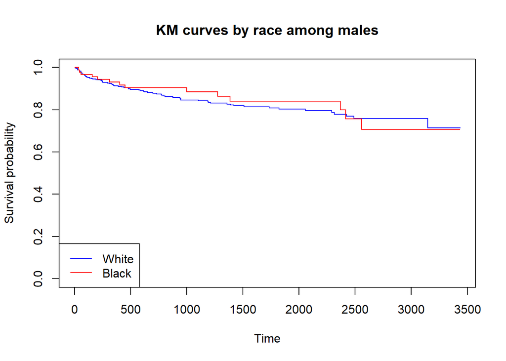

```r
# male: gender = 1
fit_male <- survfit(Surv(time, delta) ~ race,
                    data = kidtran,
                    subset = gender == 1)

plot(fit_male,
     col = c("blue", "red"),
     xlab = "Time",
     ylab = "Survival probability",
     main = "KM curves by race among males")

legend("bottomleft",
       legend = c("White", "Black"),
       col = c("blue", "red"),
       lty = 1)
```

```r
survdiff(Surv(time, delta) ~ race,
         data = kidtran,
         subset = gender == 1)
```

```
## Call:
## survdiff(formula = Surv(time, delta) ~ race, data = kidtran,
##     subset = gender == 1)
##
##          N Observed Expected (O-E)^2/E (O-E)^2/V
## race=1 432       73     71.9    0.0168     0.097
## race=2  92       14     15.1    0.0801     0.097
##
##  Chisq= 0.1  on 1 degrees of freedom, p= 0.8
```

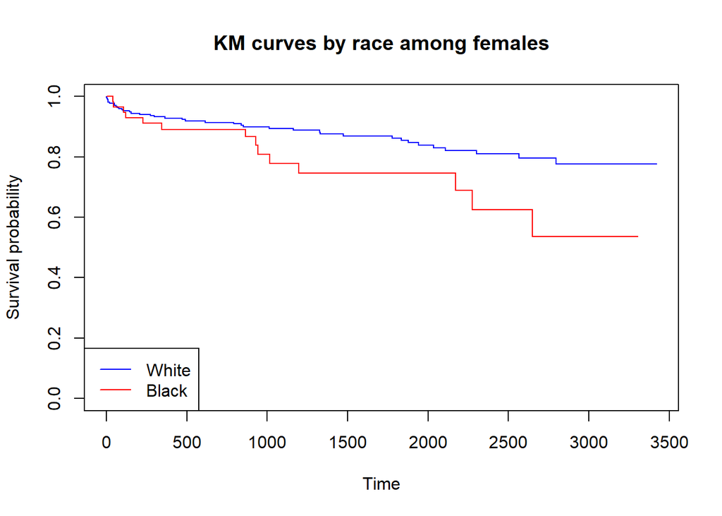

```r
# female: gender = 2
fit_female <- survfit(Surv(time, delta) ~ race,
                      data = kidtran,
                      subset = gender == 2)

plot(fit_female,
     col = c("blue", "red"),
     xlab = "Time",
     ylab = "Survival probability",
     main = "KM curves by race among females")

legend("bottomleft",
       legend = c("White", "Black"),
       col = c("blue", "red"),
       lty = 1)
```

```r
survdiff(Surv(time, delta) ~ race,
         data = kidtran,
         subset = gender == 2)
```

```
## Call:
## survdiff(formula = Surv(time, delta) ~ race, data = kidtran,
##     subset = gender == 2)
##
##          N Observed Expected (O-E)^2/E (O-E)^2/V
## race=1 280       39    44.79     0.748      4.85
## race=2  59       14     8.21     4.076      4.85
##
##  Chisq= 4.8  on 1 degrees of freedom, p= 0.03
```

The racial difference in survival appears to depend on sex. Among males, the survival curves for white and black patients are very similar. Among females, however, black patients appear to have lower survival probabilities than white patients, especially after approximately 900 days of follow-up.

# 3 Problem Three

```r
data("larynx")
```

```r
larynx$Z1 <- ifelse(larynx$stage == 2, 1, 0)
larynx$Z2 <- ifelse(larynx$stage == 3, 1, 0)
larynx$Z3 <- ifelse(larynx$stage == 4, 1, 0)
larynx$Z4 <- larynx$age

fit3 <- coxph(
  Surv(time, delta) ~ Z1 + Z2 + Z3 + Z4 + Z1:Z4,
  data = larynx
)

summary(fit3)
```

```
## Call:
## coxph(formula = Surv(time, delta) ~ Z1 + Z2 + Z3 + Z4 + Z1:Z4,
##     data = larynx)
##
##   n= 90, number of events= 50
##
##             coef  exp(coef)   se(coef)      z Pr(>|z|)
## Z1    -7.4898902  0.0005587  3.4169200 -2.192   0.0284 *
## Z2     0.6251294  1.8684878  0.3558360  1.757   0.0790 .
## Z3     1.7681449  5.8599725  0.4237680  4.172 3.01e-05 ***
## Z4     0.0060299  1.0060481  0.0148750  0.405   0.6852
## Z1:Z4  0.1133273  1.1199985  0.0478711  2.367   0.0179 *
## ---
## Signif. codes:  0 '***' 0.001 '**' 0.01 '*' 0.05 '.' 0.1 ' ' 1
##
##       exp(coef) exp(-coef) lower .95 upper .95
## Z1    0.0005587  1789.8556 6.898e-07    0.4526
## Z2    1.8684878     0.5352 9.303e-01    3.7530
## Z3    5.8599725     0.1706 2.554e+00   13.4464
## Z4    1.0060481     0.9940 9.771e-01    1.0358
## Z1:Z4 1.1199985     0.8929 1.020e+00    1.2302
##
## Concordance= 0.682  (se = 0.04 )
## Likelihood ratio test= 24.49  on 5 df,   p=2e-04
## Wald test            = 24.14  on 5 df,   p=2e-04
## Score (logrank) test = 28.49  on 5 df,   p=3e-05
```

```r
coef_fit <- coef(fit3)

RR_50 <- exp(coef_fit["Z1"] + 50 * coef_fit["Z1:Z4"])

RR_50
```

```
##        Z1
## 0.1614558
```

A Cox proportional hazards model was fitted with indicators for stage II, stage III, and stage IV, age, and an interaction between stage II and age. The fitted model is

$$\hat h(t \mid Z)
=
\hat h_0(t)
\exp\left(
-7.4899Z_1
+0.6251Z_2
+1.7681Z_3
+0.0060Z_4
+0.1133Z_1Z_4
\right).$$

The overall model is statistically significant based on the likelihood ratio test, Wald test, and score test:

$$\text{Likelihood ratio test}=24.49, \quad p=2\times 10^{-4},$$

$$\text{Wald test}=24.14, \quad p=2\times 10^{-4},$$

and

$$\text{Score log-rank test}=28.49, \quad p=3\times 10^{-5}.$$

Thus, there is evidence that at least one of the covariates is associated with the hazard of death.

Stage IV is significantly associated with a higher hazard of death compared with stage I. The estimated hazard ratio is

$$HR_{\text{stage IV vs stage I}}
=
\exp(1.7681)
=
5.8600.$$

Stage III has an estimated hazard ratio of

$$HR_{\text{stage III vs stage I}}
=
\exp(0.6251)
=
1.8685,$$

but this effect is not statistically significant at the 0.05 level.

Because the model includes an interaction term between stage II and age, the effect of stage II relative to stage I depends on age. For a patient aged $a$, the hazard ratio comparing stage II with stage I is

$$HR_{\text{stage II vs stage I at age }a}
=
\exp(\hat\beta_1+a\hat\beta_5).$$

Using the fitted coefficients, this becomes

$$HR_{\text{stage II vs stage I at age }a}
=
\exp(-7.4899+0.1133a).$$

Therefore, for a 50-year-old stage II patient compared with a 50-year-old stage I patient, the estimated relative risk of dying is

$$RR
=
\exp(-7.4899+50\times 0.1133)
=
\exp(-1.8249)
\approx 0.161.$$

Thus, according to this fitted model, a 50-year-old stage II patient has about 0.161 times the hazard of death of a 50-year-old stage I patient.